# Problem: Predictive loan model for an applicant

## Objective:

Predict the risk of a loan being default based on the past loan data, for a given loan applicant

Dataset:  https://drive.google.com/drive/folders/1XCKR-Gdw9yziWWW6TVvx5wvArFkP96PP

 Dataset will be provided in parts

Prep work required:

Data for 3 quarters will be provided to the students, with a select subset of features. This will be used for prep work and initial baselining.

 Identification of the performance parameters to be improved, for the given problem statement

 Baseline performance figures for 5 different ML classifiers, after minimal data pre-processing, Baseline figures must include (i) accuracy (ii) classification report (iii) confusion matrix (iv) ROC-AUC and AUPRC scores. One of the classifiers must be ANN.

 Observations from exploratory analysis of the dataset

 Outline of feature engineering techniques that may be used to improve the classifier performance

# Performance

Session 1:

The complete dataset (with data for 2 more years and all features) will be provided.  Shortlist 3 best performing classifiers, from the prep work  Apply relevant feature engineering techniques on the dataset provided  Compare the performance of the 3 classifiers with the baseline performance figured obtained during prep-work  Note down the features that figure high in feature ranking

Session 2:  Apply ensemble techniques to observe their impact on the performance of the classifiers

Session 3:  Group presentation

# DataSet Description:

```python
import os
import pandas as pd
def read_csv_data(dir_name):
    '''
    Arg: Directory Name
    Return: List of CSV files from a directory'''
    list_of_files=os.listdir(dir_name)
    return [file for file in list_of_files if file.endswith(".csv")]

def read_list_csv_to_pandas(list_of_csv_files):
    '''
    Arg: List of csv files name
    Return: Pandas dataframe with all file
    Assumption: ALl the files have same format'''
    pandas_list=[]
    for file in list_of_csv_files:
        pandas_list.append(pd.read_csv(os.path.join(utils['raw_data_path'],file),skiprows=1,parse_dates=['issue_d','last_pymnt_d','next_pymnt_d','last_credit_pull_d','hardship_start_date','hardship_end_date','payment_plan_start_date','debt_settlement_flag_date','settlement_date','earliest_cr_line']))
    merged_file=pd.concat(pandas_list)
    return merged_file

#After analysis we found that some are date column
```

```python
DATA_PATH='/Users/mghosh2/Downloads/loan_data/'

utils={
    'raw_data_path':DATA_PATH
}
```

## Data as provided:

Here we have data given in five different files which we have to analyze. This data is for loan risk prediction. Where "Loan Status" is the column which suggests what happens to the previously given loan. So previous risky loan and their features are documented. We should here analyze the data and try to figure out the important character of the data set

Data given is in CSV format. We should print top 5 lines and try to make sense of the data. It seems first row is not important.

Update: Dataset has date columns which is being captured as character data , so we made minute change in our code to read them as date object for making some meaningful processing later

```python
list_of_files=read_csv_data(utils['raw_data_path'])
list_of_files
```

```
['LoanStats_securev1_2017Q1.csv',
 'LoanStats_securev1_2017Q2.csv',
 'LoanStats3c_securev1_2014.csv',
 'LoanStats_securev1_2017Q3.csv',
 'LoanStats3d_securev1_2015.csv']
```

```python
!head -n 5 /Users/mghosh2/Downloads/loan_data/LoanStats_securev1_2017Q1.csv
## It looks like first row is not useful
```

```
Notes offered by Prospectus (https://www.lendingclub.com/info/prospectus.action)
"id","member_id","loan_amnt","funded_amnt","funded_amnt_inv","term","int_rate","installment","grade","sub_grade","emp_title","emp_length","home_ownership","annual_inc","verification_status","issue_d","loan_status","pymnt_plan","url","desc","purpose","title","zip_code","addr_state","dti","delinq_2yrs…
"104046719","","14000","14000","14000"," 36 months"," 15.99%","492.13","C","C5","Project Leader","10+ years","MORTGAGE","82000","Source Verified","Mar-2017","Current","n","https://lendingclub.com/browse/loanDetail.action?loan_id=104046719","","credit_card","Credit card refinancing","672xx","KS","31.…
"104048967","","5000","5000","5000"," 36 months"," 25.49%","200.1","E","E4","Pilot","10+ years","MORTGAGE","215000","Source Verified","Mar-2017","Current","n","https://lendingclub.com/browse/loanDetail.action?loan_id=104048967","","debt_consolidation","Debt consolidation","067xx","CT","6.06","0","Ja…
"104028593","","4600","4600","4600"," 36 months"," 11.39%","151.45","B","B3","cable technician","4 years","RENT","44470","Not Verified","Mar-2017","Current","n","https://lendingclub.com/browse/loanDetail.action?loan_id=104028593","","credit_card","Credit card refinancing","066xx","CT","13.43","0","D…
```

We should print top few rows and bottom few rows to get the sense of data set

```python
import warnings
warnings.filterwarnings('ignore')
pd.set_option('display.max_columns', 152)
data_raw = read_list_csv_to_pandas(list_of_files)
data_raw.head()
```

|  | id | member_id | loan_amnt | funded_amnt | funded_amnt_inv | term | int_rate | installment | grade | sub_grade | emp_title | emp_length | home_ownership | annual_inc | verification_status | issue_d | loan_status | pymnt_plan | url | desc | purpose | title | zip_code | addr_state | dti | delinq_2yrs | earliest_cr_line | fico_range_low | fico_range_high | … |
| --- | --- | --- | --- | --- | --- | --- | --- | --- | --- | --- | --- | --- | --- | --- | --- | --- | --- | --- | --- | --- | --- | --- | --- | --- | --- | --- | --- | --- | --- | --- |
| 0 | 104046719 | NaN | 14000.0 | 14000.0 | 14000.0 | 36 months | 15.99% | 492.13 | C | C5 | Project Leader | 10+ years | MORTGAGE | 82000.0 | Source Verified | 2017-03-01 | Current | n | https://lendingclub.com/browse/loanDetail.acti... | NaN | credit_card | Credit card refinancing | 672xx | KS | 31.07 | 0.0 | 1996-05-01 | 725.0 | 729.0 | … |
| 1 | 104048967 | NaN | 5000.0 | 5000.0 | 5000.0 | 36 months | 25.49% | 200.10 | E | E4 | Pilot | 10+ years | MORTGAGE | 215000.0 | Source Verified | 2017-03-01 | Current | n | https://lendingclub.com/browse/loanDetail.acti... | NaN | debt_consolidation | Debt consolidation | 067xx | CT | 6.06 | 0.0 | 2004-01-01 | 765.0 | 769.0 | … |
| 2 | 104028593 | NaN | 4600.0 | 4600.0 | 4600.0 | 36 months | 11.39% | 151.45 | B | B3 | cable technician | 4 years | RENT | 44470.0 | Not Verified | 2017-03-01 | Current | n | https://lendingclub.com/browse/loanDetail.acti... | NaN | credit_card | Credit card refinancing | 066xx | CT | 13.43 | 0.0 | 2003-12-01 | 770.0 | 774.0 | … |
| 3 | 104046702 | NaN | 14000.0 | 14000.0 | 14000.0 | 60 months | 12.74% | 316.69 | C | C1 | Specialty Sales | 4 years | OWN | 40000.0 | Not Verified | 2017-03-01 | Current | n | https://lendingclub.com/browse/loanDetail.acti... | NaN | credit_card | Credit card refinancing | 926xx | CA | 17.48 | 0.0 | 1974-02-01 | 715.0 | 719.0 | … |
| 4 | 104280113 | NaN | 15000.0 | 15000.0 | 15000.0 | 36 months | 5.32% | 451.73 | A | A1 | Executive Account Manager | 10+ years | MORTGAGE | 182000.0 | Not Verified | 2017-03-01 | Current | n | https://lendingclub.com/browse/loanDetail.acti... | NaN | debt_consolidation | Debt consolidation | 751xx | TX | 9.35 | 0.0 | 1974-11-01 | 740.0 | 744.0 | … |

```python
data_raw.tail()
```

|  | id | member_id | loan_amnt | funded_amnt | funded_amnt_inv | term | int_rate | installment | grade | sub_grade | emp_title | emp_length | home_ownership | annual_inc | verification_status | issue_d | loan_status | pymnt_plan | url | desc | purpose | title | zip_code | addr_state | dti | delinq_2yrs | earliest_cr_line | fico_range_low | fico_range_high | … |
| --- | --- | --- | --- | --- | --- | --- | --- | --- | --- | --- | --- | --- | --- | --- | --- | --- | --- | --- | --- | --- | --- | --- | --- | --- | --- | --- | --- | --- | --- | --- |
| 421092 | 36271333 | NaN | 13000.0 | 13000.0 | 13000.0 | 60 months | 15.99% | 316.07 | D | D2 | Radiologist Technologist | 5 years | RENT | 35000.0 | Verified | 2015-01-01 | Charged Off | n | https://lendingclub.com/browse/loanDetail.acti... | NaN | debt_consolidation | Debt consolidation | 378xx | TN | 30.90 | 0.0 | 2003-09-01 | 680.0 | 684.0 | … |
| 421093 | 36490806 | NaN | 12000.0 | 12000.0 | 12000.0 | 60 months | 19.99% | 317.86 | E | E3 | Painter | 1 year | RENT | 64400.0 | Source Verified | 2015-01-01 | Charged Off | n | https://lendingclub.com/browse/loanDetail.acti... | NaN | debt_consolidation | Debt consolidation | 010xx | MA | 27.19 | 1.0 | 2003-10-01 | 695.0 | 699.0 | … |
| 421094 | 36271262 | NaN | 20000.0 | 20000.0 | 20000.0 | 36 months | 11.99% | 664.20 | B | B5 | Manager Hotel Operations Oasis | 10+ years | RENT | 100000.0 | Verified | 2015-01-01 | Fully Paid | n | https://lendingclub.com/browse/loanDetail.acti... | NaN | credit_card | Credit card refinancing | 331xx | FL | 10.83 | 0.0 | 2001-12-01 | 675.0 | 679.0 | … |
| 421095 | Total amount funded in policy code 1: 6417608175 | NaN | NaN | NaN | NaN | NaN | NaN | NaN | NaN | NaN | NaN | NaN | NaN | NaN | NaN | NaT | NaN | NaN | NaN | NaN | NaN | NaN | NaN | NaN | NaN | NaN | NaT | NaN | NaN | … |
| 421096 | Total amount funded in policy code 2: 1944088810 | NaN | NaN | NaN | NaN | NaN | NaN | NaN | NaN | NaN | NaN | NaN | NaN | NaN | NaN | NaT | NaN | NaN | NaN | NaN | NaN | NaN | NaN | NaN | NaN | NaN | NaT | NaN | NaN | … |

First of all we find that there are many columns with most of the missing values

Now we need top get the details of column names as column names are too many

```python
", ".join(list(data_raw.columns))
```

```
'id, member_id, loan_amnt, funded_amnt, funded_amnt_inv, term, int_rate, installment, grade, sub_grade, emp_title, emp_length, home_ownership, annual_inc, verification_status, issue_d, loan_status, pymnt_plan, url, desc, purpose, title, zip_code, addr_state, dti, delinq_2yrs, earliest_cr_line, fico_…
```

```python
pd.set_option('display.max_rows', 152)
data_raw.dtypes
```

```
id                                                    object
member_id                                            float64
loan_amnt                                            float64
funded_amnt                                          float64
funded_amnt_inv                                      float64
term                                                  object
int_rate                                              object
installment                                          float64
grade                                                 object
sub_grade                                             object
emp_title                                             object
emp_length                                            object
home_ownership                                        object
annual_inc                                           float64
verification_status                                   object
issue_d                                       datetime64[ns]
loan_status                                           object
pymnt_plan                                            object
url                                                   object
desc                                                  object
purpose                                               object
title                                                 object
zip_code                                              object
addr_state                                            object
dti                                                  float64
delinq_2yrs                                          float64
earliest_cr_line                              datetime64[ns]
fico_range_low                                       float64
fico_range_high                                      float64
inq_last_6mths                                       float64
mths_since_last_delinq                               float64
mths_since_last_record                               float64
open_acc                                             float64
pub_rec                                              float64
revol_bal                                            float64
revol_util                                            object
total_acc                                            float64
initial_list_status                                   object
out_prncp                                            float64
out_prncp_inv                                        float64
```

[output cut: 97 more lines]

```
hardship_length                                      float64
hardship_dpd                                         float64
hardship_loan_status                                  object
orig_projected_additional_accrued_interest           float64
hardship_payoff_balance_amount                       float64
hardship_last_payment_amount                         float64
disbursement_method                                   object
debt_settlement_flag                                  object
debt_settlement_flag_date                     datetime64[ns]
settlement_status                                     object
settlement_date                               datetime64[ns]
settlement_amount                                    float64
settlement_percentage                                float64
settlement_term                                      float64
dtype: object
```

### Some Details of loan status columns

Here 'Current' and 'Fully Paid' are non-risky class. Rest are risky which percentage is around 12.5%

```python
data_raw['loan_status'].value_counts()
```

```
Current               500937
Fully Paid            358629
Charged Off            99099
Late (31-120 days)     13203
In Grace Period         6337
Late (16-30 days)       3414
Default                   36
Name: loan_status, dtype: int64
```

```python
data_raw['loan_status'].value_counts()/data_raw.shape[0]
```

```
Current               0.510293
Fully Paid            0.365327
Charged Off           0.100950
Late (31-120 days)    0.013450
In Grace Period       0.006455
Late (16-30 days)     0.003478
Default               0.000037
Name: loan_status, dtype: float64
```

```python
import pandas as pd
import numpy as np
import matplotlib.pyplot as plt
import seaborn as sns
from matplotlib import rcParams
from scipy import stats

#To plot figs on jupyter
%matplotlib inline
# figure size in inches
rcParams['figure.figsize'] = 14,6
```

### Now get some details of the columns

We see that some columns are having 99% or more missing. Which might not be interested to us. We shall remove them from our analysis upfront. For the rest of the data we shall employ some data imputation methods

```python
def colume_details(df):
    print(f"Dataset Shape: {df.shape}")
    summary = pd.DataFrame(df.dtypes,columns=['dtypes'])
    summary = summary.reset_index()
    summary['Name'] = summary['index']
    summary = summary[['Name','dtypes']]
    summary['Missing'] = df.isnull().sum().values
    summary['Non_Missing'] = df.shape[0] - summary['Missing']
    summary['Percent_Missing'] = summary['Missing']/df.shape[0]
    summary['Uniques'] = df.nunique().values
    summary['First Value'] = df.loc[0].values
    summary['Second Value'] = df.loc[1].values
    summary['Third Value'] = df.loc[2].values

    for name in summary['Name'].value_counts().index:
        summary.loc[summary['Name'] == name, 'Entropy'] = round(stats.entropy(df[name].value_counts(normalize=True), base=2),2)

    return summary
```

```python
data_raw=data_raw.reset_index().drop(['index'],axis=1)
column_explantion=colume_details(data_raw)

#  all the columns non-numerical or object type in python
column_explantion[column_explantion['dtypes']=='object']
```

```
Dataset Shape: (981665, 151)
```

|  | Name | dtypes | Missing | Non_Missing | Percent_Missing | Uniques | First Value | Second Value | Third Value | Entropy |
| --- | --- | --- | --- | --- | --- | --- | --- | --- | --- | --- |
| 0 | id | object | 0 | 981665 | 0.000000 | 981665 | 104046719 | 104048967 | 104028593 | 19.90 |
| 5 | term | object | 10 | 981655 | 0.000010 | 2 | 36 months | 36 months | 36 months | 0.89 |
| 6 | int_rate | object | 10 | 981655 | 0.000010 | 201 | 15.99% | 25.49% | 11.39% | 6.74 |
| 8 | grade | object | 10 | 981655 | 0.000010 | 7 | C | E | B | 2.32 |
| 9 | sub_grade | object | 10 | 981655 | 0.000010 | 35 | C5 | E4 | B3 | 4.62 |
| 10 | emp_title | object | 59595 | 922070 | 0.060708 | 232289 | Project Leader | Pilot | cable technician | 13.91 |
| 11 | emp_length | object | 57995 | 923670 | 0.059078 | 11 | 10+ years | 10+ years | 4 years | 3.04 |
| 12 | home_ownership | object | 10 | 981655 | 0.000010 | 5 | MORTGAGE | MORTGAGE | RENT | 1.38 |
| 14 | verification_status | object | 10 | 981655 | 0.000010 | 3 | Source Verified | Source Verified | Not Verified | 1.57 |
| 16 | loan_status | object | 10 | 981655 | 0.000010 | 7 | Current | Current | Current | 1.52 |
| 17 | pymnt_plan | object | 10 | 981655 | 0.000010 | 2 | n | n | n | 0.01 |
| 18 | url | object | 10 | 981655 | 0.000010 | 981655 | https://lendingclub.com/browse/loanDetail.acti... | https://lendingclub.com/browse/loanDetail.acti... | https://lendingclub.com/browse/loanDetail.acti... | 19.90 |
| 19 | desc | object | 966341 | 15324 | 0.984390 | 14876 | NaN | NaN | NaN | 13.83 |
| 20 | purpose | object | 10 | 981655 | 0.000010 | 14 | credit_card | debt_consolidation | credit_card | 1.86 |
| 21 | title | object | 142 | 981523 | 0.000145 | 2071 | Credit card refinancing | Debt consolidation | Credit card refinancing | 1.93 |
| 22 | zip_code | object | 11 | 981654 | 0.000011 | 936 | 672xx | 067xx | 066xx | 8.92 |
| 23 | addr_state | object | 10 | 981655 | 0.000010 | 51 | KS | CT | CT | 4.85 |
| 35 | revol_util | object | 550 | 981115 | 0.000560 | 1280 | 63.2% | 18.8% | 19.1% | 9.86 |
| 37 | initial_list_status | object | 10 | 981655 | 0.000010 | 2 | w | f | w | 0.93 |
| 56 | application_type | object | 10 | 981655 | 0.000010 | 2 | Individual | Individual | Individual | 0.17 |
| 59 | verification_status_joint | object | 955940 | 25725 | 0.973795 | 3 | NaN | NaN | NaN | 1.51 |
| 118 | sec_app_earliest_cr_line | object | 959840 | 21825 | 0.977767 | 564 | NaN | NaN | NaN | 8.32 |
| 128 | hardship_flag | object | 10 | 981655 | 0.000010 | 2 | N | N | N | 0.01 |
| 129 | hardship_type | object | 978661 | 3004 | 0.996940 | 1 | NaN | NaN | NaN | 0.00 |
| 130 | hardship_reason | object | 978661 | 3004 | 0.996940 | 9 | NaN | NaN | NaN | 2.34 |
| 131 | hardship_status | object | 978661 | 3004 | 0.996940 | 3 | NaN | NaN | NaN | 1.28 |
| 139 | hardship_loan_status | object | 978661 | 3004 | 0.996940 | 5 | NaN | NaN | NaN | 1.74 |
| 143 | disbursement_method | object | 10 | 981655 | 0.000010 | 2 | Cash | Cash | Cash | 0.00 |
| 144 | debt_settlement_flag | object | 10 | 981655 | 0.000010 | 2 | N | N | N | 0.07 |
| 146 | settlement_status | object | 973035 | 8630 | 0.991209 | 3 | NaN | NaN | NaN | 1.29 |

```python
# All the numerical columns

column_explantion[column_explantion['dtypes']!='object']
```

|  | Name | dtypes | Missing | Non_Missing | Percent_Missing | Uniques | First Value | Second Value | Third Value | Entropy |
| --- | --- | --- | --- | --- | --- | --- | --- | --- | --- | --- |
| 1 | member_id | float64 | 981665 | 0 | 1.000000 | 0 | NaN | NaN | NaN | 0.00 |
| 2 | loan_amnt | float64 | 10 | 981655 | 0.000010 | 1549 | 14000 | 5000 | 4600 | 6.91 |
| 3 | funded_amnt | float64 | 10 | 981655 | 0.000010 | 1549 | 14000 | 5000 | 4600 | 6.91 |
| 4 | funded_amnt_inv | float64 | 10 | 981655 | 0.000010 | 1556 | 14000 | 5000 | 4600 | 7.18 |
| 7 | installment | float64 | 10 | 981655 | 0.000010 | 67063 | 492.13 | 200.1 | 151.45 | 13.45 |
| 13 | annual_inc | float64 | 10 | 981655 | 0.000010 | 51776 | 82000 | 215000 | 44470 | 8.25 |
| 15 | issue_d | datetime64[ns] | 10 | 981655 | 0.000010 | 33 | 2017-03-01 00:00:00 | 2017-03-01 00:00:00 | 2017-03-01 00:00:00 | 4.95 |
| 24 | dti | float64 | 304 | 981361 | 0.000310 | 7006 | 31.07 | 6.06 | 13.43 | 11.74 |
| 25 | delinq_2yrs | float64 | 10 | 981655 | 0.000010 | 31 | 0 | 0 | 0 | 1.07 |
| 26 | earliest_cr_line | datetime64[ns] | 10 | 981655 | 0.000010 | 712 | 1996-05-01 00:00:00 | 2004-01-01 00:00:00 | 2003-12-01 00:00:00 | 8.43 |
| 27 | fico_range_low | float64 | 10 | 981655 | 0.000010 | 38 | 725 | 765 | 770 | 4.31 |
| 28 | fico_range_high | float64 | 10 | 981655 | 0.000010 | 38 | 729 | 769 | 774 | 4.31 |
| 29 | inq_last_6mths | float64 | 10 | 981655 | 0.000010 | 7 | 0 | 4 | 1 | 1.51 |
| 30 | mths_since_last_delinq | float64 | 477730 | 503935 | 0.486653 | 157 | NaN | NaN | NaN | 6.28 |
| 31 | mths_since_last_record | float64 | 807460 | 174205 | 0.822541 | 122 | NaN | NaN | NaN | 6.68 |
| 32 | open_acc | float64 | 10 | 981655 | 0.000010 | 84 | 18 | 11 | 7 | 4.37 |
| 33 | pub_rec | float64 | 10 | 981655 | 0.000010 | 34 | 0 | 0 | 0 | 0.84 |
| 34 | revol_bal | float64 | 10 | 981655 | 0.000010 | 77865 | 69578 | 8678 | 5400 | 15.26 |
| 36 | total_acc | float64 | 10 | 981655 | 0.000010 | 139 | 31 | 16 | 11 | 5.52 |
| 38 | out_prncp | float64 | 10 | 981655 | 0.000010 | 224610 | 11438.3 | 4190.59 | 3708.5 | 9.82 |
| 39 | out_prncp_inv | float64 | 10 | 981655 | 0.000010 | 233964 | 11438.3 | 4190.59 | 3708.5 | 9.87 |
| 40 | total_pymnt | float64 | 10 | 981655 | 0.000010 | 683576 | 3912.17 | 1586.64 | 1205.78 | 18.82 |
| 41 | total_pymnt_inv | float64 | 10 | 981655 | 0.000010 | 638309 | 3912.17 | 1586.64 | 1205.78 | 18.70 |
| 42 | total_rec_prncp | float64 | 10 | 981655 | 0.000010 | 277868 | 2561.74 | 809.41 | 891.5 | 14.25 |
| 43 | total_rec_int | float64 | 10 | 981655 | 0.000010 | 404606 | 1350.43 | 777.23 | 314.28 | 17.98 |
| 44 | total_rec_late_fee | float64 | 10 | 981655 | 0.000010 | 6685 | 0 | 0 | 0 | 0.43 |
| 45 | recoveries | float64 | 10 | 981655 | 0.000010 | 50111 | 0 | 0 | 0 | 1.22 |
| 46 | collection_recovery_fee | float64 | 10 | 981655 | 0.000010 | 52474 | 0 | 0 | 0 | 1.22 |
| 47 | last_pymnt_d | datetime64[ns] | 878 | 980787 | 0.000894 | 47 | 2017-12-01 00:00:00 | 2017-12-01 00:00:00 | 2017-12-01 00:00:00 | 3.52 |
| 48 | last_pymnt_amnt | float64 | 10 | 981655 | 0.000010 | 333115 | 492.13 | 200.1 | 151.45 | 15.88 |

[output cut: 91 more lines]

```python
# All the column types with date

column_explantion[column_explantion['dtypes']=='datetime64[ns]']
##Columns with high null values (more than ratio 0.999) are rejected
# We have to work with  'issue_d','last_pymnt_d','next_pymnt_d','last_credit_pull_d' this date columns
```

[output not shown]

So we should drop columns with very less entropy or more than 99% missing data

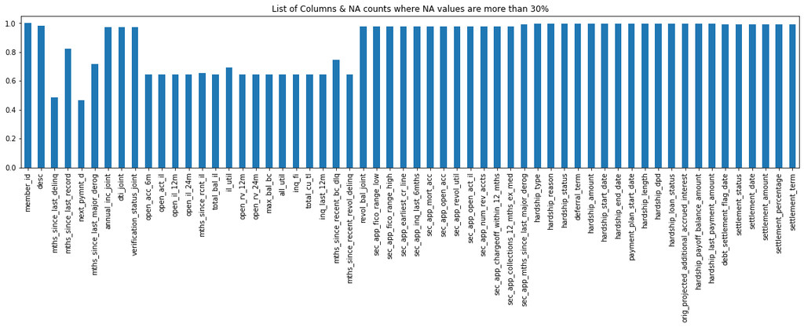

```python
# Plot all the columns with more than 30% missing data

NA_col = data_raw.isnull().sum()
NA_col = NA_col[NA_col.values >(0.3*len(data_raw))]
NA_col = NA_col / data_raw.shape[0]
plt.figure(figsize=(20,4))
NA_col.plot(kind='bar')
plt.title('List of Columns & NA counts where NA values are more than 30%')
plt.show()
```

We know that "Current" and "Fully Paid" are not risky but rest are risky. So lets explore that in the data

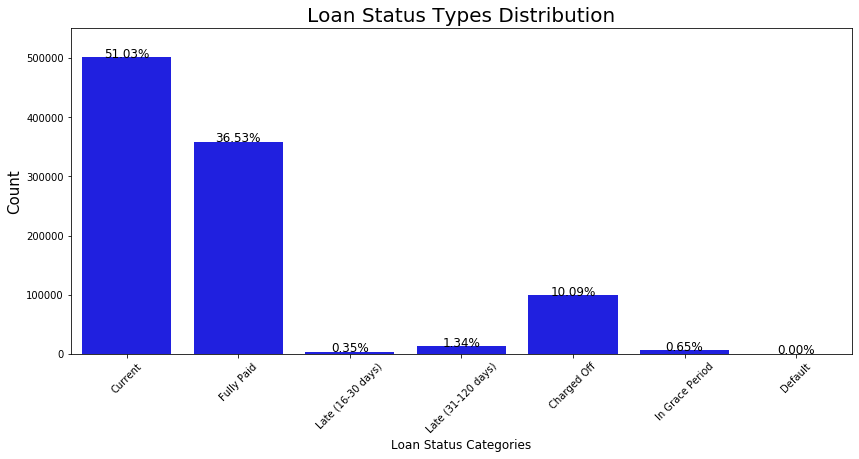

```python
import matplotlib.pyplot as plt
import seaborn as sns

total = len(data_raw)

plt.figure(figsize = (14,6))

g = sns.countplot(x="loan_status", data=data_raw,
                  color='blue')
g.set_xticklabels(g.get_xticklabels(),rotation=45)
g.set_xlabel("Loan Status Categories", fontsize=12)
g.set_ylabel("Count", fontsize=15)
g.set_title("Loan Status Types Distribution", fontsize=20)
sizes=[]
for p in g.patches:
    height = p.get_height()
    sizes.append(height)
    g.text(p.get_x()+p.get_width()/2.,
            height + 3,
            '{:1.2f}%'.format(height/total*100),
            ha="center", fontsize=12)
g.set_ylim(0, max(sizes) * 1.10)

plt.show()
```

After Observing we found that 'int_rate' and 'revol_util' should be float. So we have to process with some regex

Also we take the list of blank columns so that we san drop them from our analysis data

```python
# We have to clean some columns like interest rate etc
import re
def int_rate_pick(text):
    text=str(text).strip()
    try:
        if len(text) >0:
            int_rate=re.compile(r'\d+(\.\d{1,2})?')
            int_rate=int_rate.search(text)[0]
            return float(int_rate)
        else:
            return 0
    except:
        return 0

##Looking at the data it looks 2018-01 last quarter. So we consider epoc 2018-02 when we have the data and doing analysis
from datetime import datetime

def date_diff(col_value_provided,today=datetime(2018,2,1,0,0,0)):
    diff = today-col_value_provided
    return diff.days
# int_rate_pick('nan' )
# date_diff(datetime(2018,1,1,0,0,0))
```

```python
#columns with maximum Blank. 5 are printed
blank_columns=list(column_explantion[column_explantion['Percent_Missing'] > 0.99]['Name'].values)
blank_columns
```

```
['member_id',
 'sec_app_mths_since_last_major_derog',
 'hardship_type',
 'hardship_reason',
 'hardship_status',
 'deferral_term',
 'hardship_amount',
 'hardship_start_date',
 'hardship_end_date',
 'payment_plan_start_date',
 'hardship_length',
 'hardship_dpd',
 'hardship_loan_status',
 'orig_projected_additional_accrued_interest',
 'hardship_payoff_balance_amount',
 'hardship_last_payment_amount',
 'debt_settlement_flag_date',
 'settlement_status',
 'settlement_date',
 'settlement_amount',
 'settlement_percentage',
 'settlement_term']
```

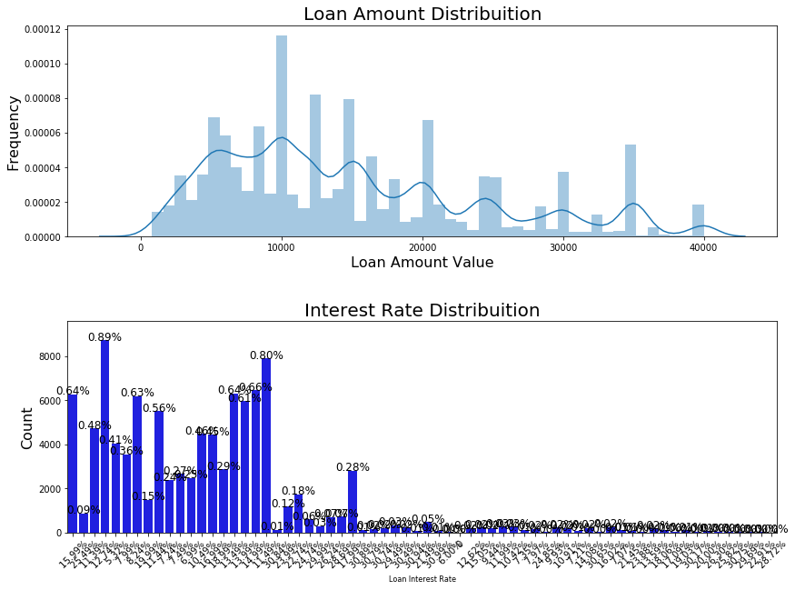

```python
#Loan Amount and Interest Rate distribution

#I will start looking the loan_amnt column
plt.figure(figsize=(14,10))

# Loan Amt plot
plt.subplot(211)
g = sns.distplot(data_raw[:100000].fillna(0)["loan_amnt"])
g.set_xlabel("Loan Amount Value", fontsize=16)
g.set_ylabel("Frequency", fontsize=16)
g.set_title("Loan Amount Distribuition", fontsize=20)

## Interest plot
plt.subplot(212)
g1 = sns.countplot(x="int_rate", data=data_raw[:100000].fillna(0),
                  color='blue')
g1.set_xlabel("Loan Interest Rate", fontsize=8)
g1.set_ylabel("Count", fontsize=16)
g1.set_title("Interest Rate Distribuition", fontsize=20)
sizes=[] # Get highest values in y
for p in g1.patches:
    height = p.get_height()
    sizes.append(height)
    g1.text(p.get_x()+p.get_width()/2.,
            height + 3,
            '{:1.2f}%'.format(height/total*100),
            ha="center", fontsize=12)
g1.set_xticklabels(g1.get_xticklabels(),rotation=45)
g1.set_ylim(0, max(sizes) * 1.10) # set y limit based on highest heights

plt.subplots_adjust(hspace = 0.4,top = 0.9)

plt.show()
```

```python
# importtant date column for feature creation. 'issue_d','last_pymnt_d','next_pymnt_d','last_credit_pull_d'
# Drop columns to reduce the data size
data_raw=data_raw.drop(blank_columns,axis=1)

data_raw['int_rate_float']=data_raw['int_rate'].apply(int_rate_pick)
data_raw['revol_util_float']=data_raw['revol_util'].apply(int_rate_pick)
data_raw['days_since_issue']=data_raw['issue_d'].apply(date_diff)
data_raw['days_since_last_payment']=data_raw['last_pymnt_d'].apply(date_diff)
data_raw['days_since_next_payment']=data_raw['next_pymnt_d'].apply(date_diff)
data_raw['days_since_last_credit_pull']=data_raw['last_credit_pull_d'].apply(date_diff)
data_raw['years_since_credit_line']=data_raw['earliest_cr_line'].apply(date_diff).apply(lambda x: x/365)

data_raw.drop(['last_pymnt_d','next_pymnt_d','last_credit_pull_d','int_rate','revol_util','earliest_cr_line'],axis=1)
data_raw.head()
```

|  | id | loan_amnt | funded_amnt | funded_amnt_inv | term | int_rate | installment | grade | sub_grade | emp_title | emp_length | home_ownership | annual_inc | verification_status | issue_d | loan_status | pymnt_plan | url | desc | purpose | title | zip_code | addr_state | dti | delinq_2yrs | earliest_cr_line | fico_range_low | fico_range_high | inq_last_6mths | … |
| --- | --- | --- | --- | --- | --- | --- | --- | --- | --- | --- | --- | --- | --- | --- | --- | --- | --- | --- | --- | --- | --- | --- | --- | --- | --- | --- | --- | --- | --- | --- |
| 0 | 104046719 | 14000.0 | 14000.0 | 14000.0 | 36 months | 15.99% | 492.13 | C | C5 | Project Leader | 10+ years | MORTGAGE | 82000.0 | Source Verified | 2017-03-01 | Current | n | https://lendingclub.com/browse/loanDetail.acti... | NaN | credit_card | Credit card refinancing | 672xx | KS | 31.07 | 0.0 | 1996-05-01 | 725.0 | 729.0 | 0.0 | … |
| 1 | 104048967 | 5000.0 | 5000.0 | 5000.0 | 36 months | 25.49% | 200.10 | E | E4 | Pilot | 10+ years | MORTGAGE | 215000.0 | Source Verified | 2017-03-01 | Current | n | https://lendingclub.com/browse/loanDetail.acti... | NaN | debt_consolidation | Debt consolidation | 067xx | CT | 6.06 | 0.0 | 2004-01-01 | 765.0 | 769.0 | 4.0 | … |
| 2 | 104028593 | 4600.0 | 4600.0 | 4600.0 | 36 months | 11.39% | 151.45 | B | B3 | cable technician | 4 years | RENT | 44470.0 | Not Verified | 2017-03-01 | Current | n | https://lendingclub.com/browse/loanDetail.acti... | NaN | credit_card | Credit card refinancing | 066xx | CT | 13.43 | 0.0 | 2003-12-01 | 770.0 | 774.0 | 1.0 | … |
| 3 | 104046702 | 14000.0 | 14000.0 | 14000.0 | 60 months | 12.74% | 316.69 | C | C1 | Specialty Sales | 4 years | OWN | 40000.0 | Not Verified | 2017-03-01 | Current | n | https://lendingclub.com/browse/loanDetail.acti... | NaN | credit_card | Credit card refinancing | 926xx | CA | 17.48 | 0.0 | 1974-02-01 | 715.0 | 719.0 | 0.0 | … |
| 4 | 104280113 | 15000.0 | 15000.0 | 15000.0 | 36 months | 5.32% | 451.73 | A | A1 | Executive Account Manager | 10+ years | MORTGAGE | 182000.0 | Not Verified | 2017-03-01 | Current | n | https://lendingclub.com/browse/loanDetail.acti... | NaN | debt_consolidation | Debt consolidation | 751xx | TX | 9.35 | 0.0 | 1974-11-01 | 740.0 | 744.0 | 0.0 | … |

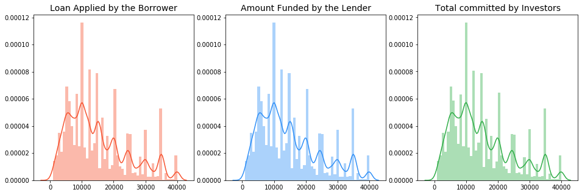

```python
fig, ax = plt.subplots(1, 3, figsize=(16,5))

loan_amount = data_raw["loan_amnt"][:100000].fillna(0).values
funded_amount = data_raw["funded_amnt"][:100000].fillna(0).values
investor_funds = data_raw["funded_amnt_inv"][:100000].fillna(0).values

sns.distplot(loan_amount, ax=ax[0], color="#F7522F")
ax[0].set_title("Loan Applied by the Borrower", fontsize=14)
sns.distplot(funded_amount, ax=ax[1], color="#2F8FF7")
ax[1].set_title("Amount Funded by the Lender", fontsize=14)
sns.distplot(investor_funds, ax=ax[2], color="#2EAD46")
ax[2].set_title("Total committed by Investors", fontsize=14)
plt.show()
```

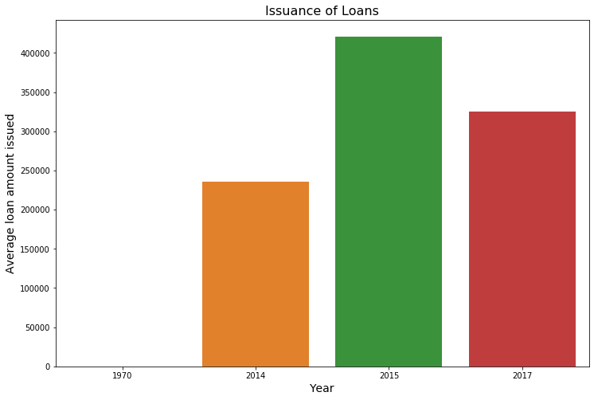

```python
# The year of 2015 was the year were the highest amount of loans were issued
from collections import Counter
plt.figure(figsize=(12,8))
year=data_raw['issue_d'].fillna(0).apply(lambda x: pd.to_datetime(x).year)
sns.barplot(list(Counter(year).keys()),list(Counter(year).values()), palette='tab10')
plt.title('Issuance of Loans', fontsize=16)
plt.xlabel('Year', fontsize=14)
plt.ylabel('Average loan amount issued', fontsize=14)
plt.show()
```

## Installment by loan Status

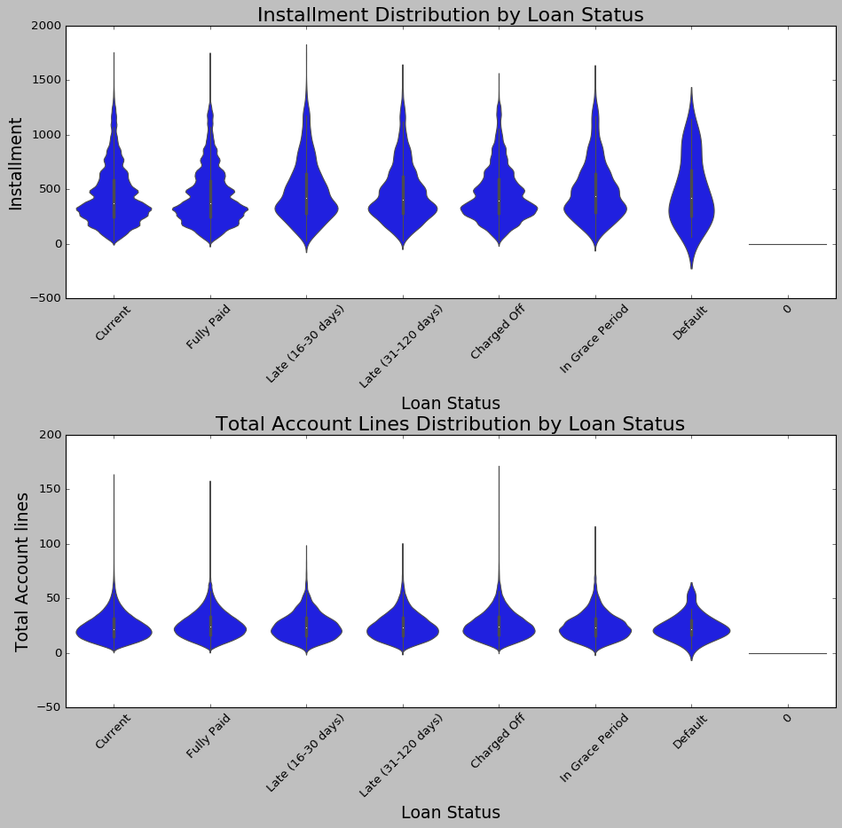

```python
plt.figure(figsize = (14,12))

plt.subplot(211)
g = sns.violinplot(x='loan_status', y="installment",
                   data=data_raw.fillna(0), color='blue')
g.set_xticklabels(g.get_xticklabels(),rotation=45)
g.set_xlabel("Loan Status", fontsize=17)
g.set_ylabel("Installment", fontsize=17)
g.set_title("Installment Distribution by Loan Status", fontsize=20)

plt.subplot(212)
g1 = sns.violinplot(x='loan_status', y="total_acc",
                   data=data_raw.fillna(0), color='blue')
g1.set_xticklabels(g.get_xticklabels(),rotation=45)
g1.set_xlabel("Loan Status", fontsize=17)
g1.set_ylabel("Total Account lines", fontsize=17)
g1.set_title("Total Account Lines Distribution by Loan Status", fontsize=20)

plt.subplots_adjust(hspace = 0.5,top = 0.9)

plt.show()
```

## Home Ownership by Loan amount

```python
plt.figure(figsize = (14,12))

plt.subplot(211)
g = sns.violinplot(x="home_ownership",y="loan_amnt",data=data_raw.fillna(0),
               kind="violin",
               split=True,palette="hls",
               hue="application_type")
g.set_title("Homer Ownership - Loan Amount Distribuition", fontsize=20)
g.set_xlabel("", fontsize=15)
g.set_ylabel("Loan Amount", fontsize=15)

plt.subplot(212)
g1 = sns.violinplot(x="home_ownership",y="int_rate",data=data_raw.fillna(0),
               kind="violin",
               split=True,palette="hls",
               hue="application_type")
g1.set_title("Homer Ownership - Interest Rate Distribuition", fontsize=20)
g1.set_xlabel("", fontsize=15)
g1.set_ylabel("Interest Rate", fontsize=15)

plt.subplots_adjust(hspace = 0.3,top = 0.9)

plt.show()
```

[output not shown]

## Top 40 Employment Title

```python
emp_title=data_raw['emp_title'].value_counts(normalize=True) * 100
emp_title[:40]
```

```
Teacher                     2.052556
Manager                     1.753988
Owner                       1.028881
Registered Nurse            0.828570
RN                          0.796252
Supervisor                  0.750702
Sales                       0.675003
Driver                      0.646480
Project Manager             0.591604
Office Manager              0.518833
Director                    0.488683
General Manager             0.481091
owner                       0.459293
manager                     0.420142
teacher                     0.404742
President                   0.404742
Engineer                    0.392270
Vice President              0.338803
Operations Manager          0.320041
driver                      0.319932
Attorney                    0.309087
Accountant                  0.295531
Administrative Assistant    0.288807
Sales Manager               0.284794
Account Manager             0.251933
Nurse                       0.248897
Police Officer              0.244992
Executive Assistant         0.232629
sales                       0.232087
Technician                  0.232087
Truck Driver                0.228182
Analyst                     0.227532
Store Manager               0.219940
supervisor                  0.218964
Paralegal                   0.198792
Software Engineer           0.194562
Server                      0.186971
Consultant                  0.185669
Controller                  0.184368
Program Manager             0.178945
Name: emp_title, dtype: float64
```

## Employee Length

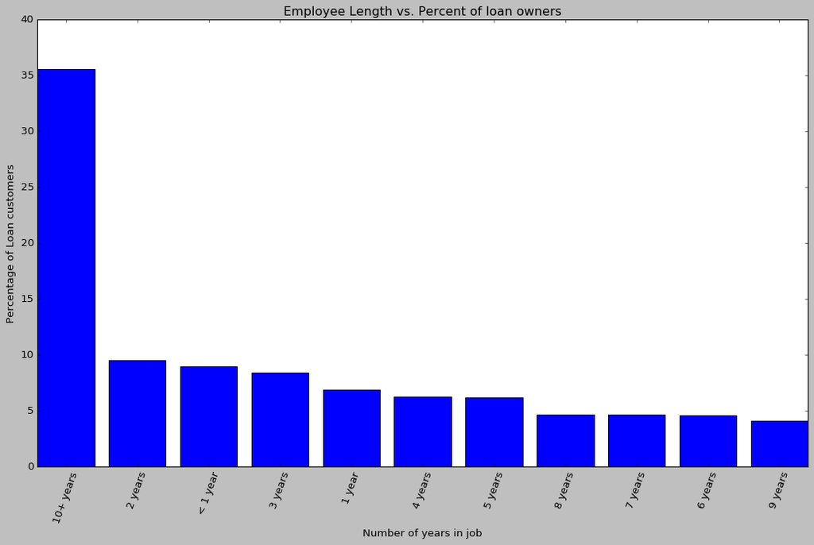

```python
plt.figure(figsize = (16,9))

emp_length=data_raw.emp_length.value_counts(normalize=True) * 100
plt.bar(emp_length.index,emp_length)

#xticks
plt.xticks(rotation=70)

#x-axis labels
plt.xlabel('Number of years in job')

#y-axis labels
plt.ylabel('Percentage of Loan customers')

#plot title
plt.title('Employee Length vs. Percent of loan owners')

#display
plt.show();
```